# Climate Change Report

Clarissa, Quynh, Brendan, Ethan

2/19/2021

## Introduction

The data set, [Daily Temperatures of Major Cities](https://www.kaggle.com/sudalairajkumar/daily-temperature-of-major-cities), was found on Kaggle and was collected by a data scientist at H2O.ai, an open source software company in Silicon Valley. There are 1,048,575 observations in this data set with eight features: region, country, start, city, month, day, year, and average temperature. This data set will go a long way in determining where the highest changes in temperature occurred and will allow us to measure multiple climate change variables. We will be able to answer questions such as: Which states have experienced the highest temperature change over time? Based on current temperature patterns, which cities will be heavily impacted by climate change and global warming in the near future?

## Summary

Our data analysis has extracted certain observations that have given us the following variables. The highest average temperature is 110 degrees fahrenheit. The highest average temperature occurred on 8, 1, 2012. The highest average temperature was found in Middle East, Kuwait, , Kuwait. The most recent highest average temperature was 92.9. This max average temperature occurred in Africa, Nigeria, , Niamey.

## Tables

Comparing mean and max temperature in Seattle during 1995 and 2019

| Months | Mean Temp - 1995 | Mean Temp - 2019 | Max Temp - 1995 | Max Temp - 2019 |
| --- | --- | --- | --- | --- |
| January | 46.1 | 44.6 | 53.5 | 51.1 |
| February | 45.6 | 36.6 | 56.2 | 48.2 |
| March | 47.4 | 47.7 | 58.9 | 68.1 |
| April | 50.8 | 51.9 | 59.7 | 59.8 |
| May | 59.9 | 59.9 | 70.8 | 71.7 |
| June | 62.0 | 62.4 | 80.2 | 77.6 |
| July | 66.5 | 66.7 | 79.3 | 73.3 |
| August | 62.3 | 68.1 | 70.6 | 74.9 |
| September | 63.2 | 62.0 | 72.2 | 69.6 |
| October | 51.9 | 50.9 | 57.4 | 57.7 |
| November | 48.8 | 46.4 | 58.0 | 52.9 |
| December | 41.9 | 44.4 | 52.0 | 51.7 |

The table displayed includes key information that compares the average and maximum monthly temperatures for Seattle, Washington in the year 1995 and 2019. We have included the information in this table as it conveys that the trends in temperature in Seattle throughout the entire year. As shown in the table, temperatures in 1995 were more consistent as it gradually became hotter in the June and July and then became colder. However, in 2019, temperatures had more variation which can further imply the correlation of the effects of climate change.

## Charts

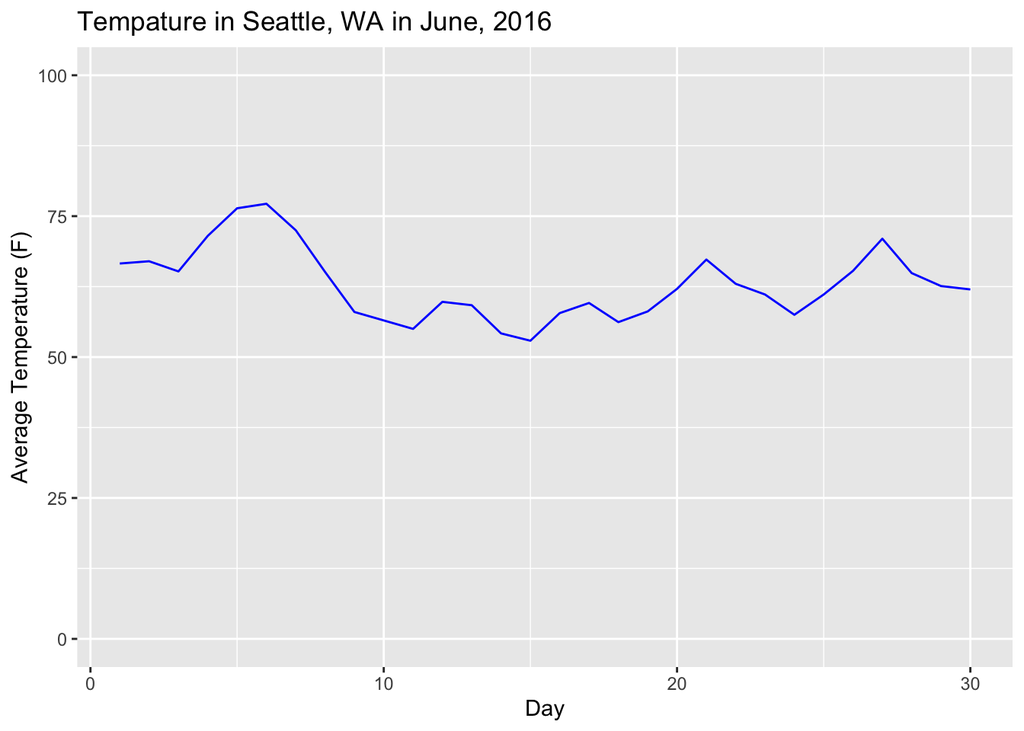

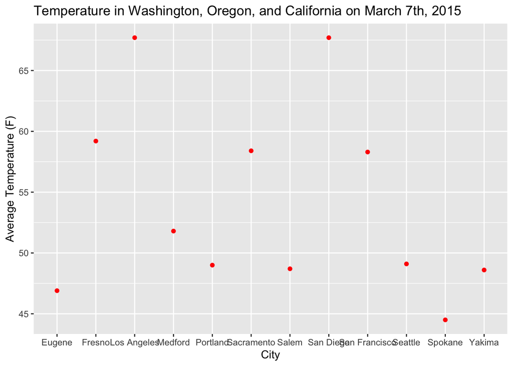

This chart is a scatterplot that compares cities the average temperatures in cities in Washington, Oregon and California on March 7th, 2015.

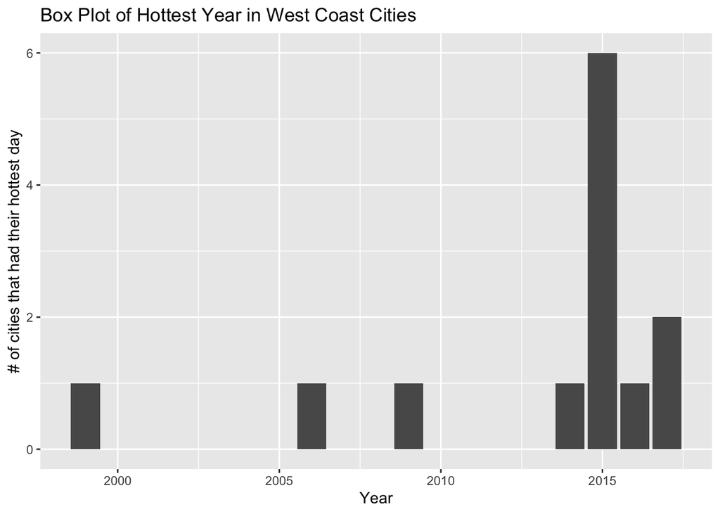

This barchart conveys the which years certain West Coast cities have experienced their hottest temperatures in on a given day.